# Chapter C7

## 圧縮における複合形状および補強板パネルの圧潰強度

### 板有効幅。柱強度。

**C7.1 イントロダクション**

第C6章では、圧縮荷重を受けた場合の複合断面の局所座屈応力を扱った。フランジ板要素から構成される断面の短い供試体の試験では、断面が局所座屈した後でも、部材は破壊が発生する前により大きな荷重を支持する能力を依然として有していることがよく示される。言い換えれば、局所座屈荷重と局所破壊（圧潰）荷重は同じではない。低い応力で局所座屈が発生する場合、圧潰または破壊応力は高くなる。0.7から0.8 $F_{cy}$ のような高い応力で局所座屈が発生する場合、座屈応力と圧潰応力は実質的に同じである。図 C7.1は、局所座屈が発生した後、局所圧潰または破壊に至る前の断面上の応力分布を示している。

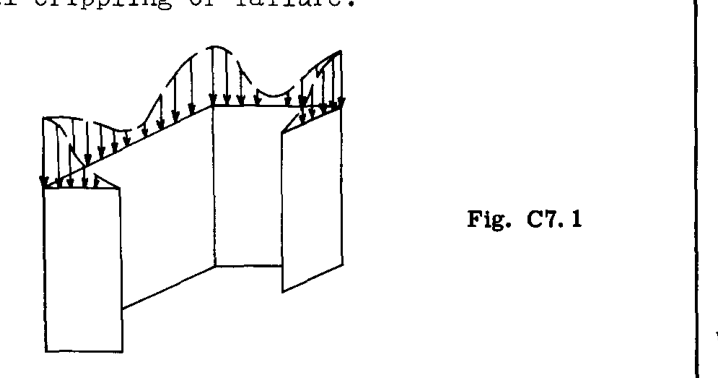

Fig. C7.1

断面への荷重が増加するにつれて、平坦な部分の座屈は大きくなるが、増加する荷重の大部分は、応力強度が破壊を引き起こすのに十分な変形を生じさせるほどの高い値に達するまで、はるかに剛性の高い角部に伝達される。

フランジと板要素の間の境界拘束が未知であり、また角部における応力の蓄積の仕方が十分に理解されていないため、すべての種類の形状に対する局所圧潰応力の理論的解法は開発されていない。したがって、解決方法は半経験的な特徴を持ち、そのような方法の結果は試験によって十分に実証されている。本章では、圧潰応力を計算する2つの方法を提示する。

**C7.2 方法1. アングル法、またはNeedham法。**

アングル法またはNeedham法と呼ばれるこの方法は、（文献1）で提示された。この方法では、図 C7.2に示すように、部材の断面を等しいかまたは等しくないアングル（L字形）要素に分割する。これらのアングル要素の強度は、理論または試験によって確立できる。その後、複合断面を構成するアングル要素の強度を加算することにより、極限強度または破壊強度を求めることができる。

Needhamは、アングルおよびチャンネル（溝形）断面について多数の試験を行った。これらの試験結果およびチャンネル、正方形および長方形管などに関する他の公表された試験データの研究から、彼はアングル断面の圧潰または破壊応力について次の式に到達した。

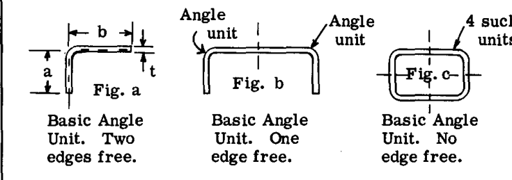

Fig. C7.2

$$\frac{F_{cs}}{(F_{cy} E)^{1/2}} = \frac{C_e}{(b'/t)^{0.75}}
\qquad ---\text{(C7.1)}$$

ここで、

- $F_{cs}$ = 圧潰応力 (psi)
- $F_{cy}$ = 圧縮降伏応力 (psi)
- $E$ = 圧縮における縦弾性係数 (psi)
- $b'/t$ = 断面の等価 $b/t = (a + b)/2t$
- $C_e$ = 隣接するアングル要素の端部に沿った端部支持の程度に依存する係数。具体的には以下の通りである：
- $C_e = 0.316$ （2辺自由）
- $C_e = 0.342$ （1辺自由）
- $C_e = 0.366$ （自由辺なし）

アングル、チャンネル、ゼット、および長方形管の圧潰応力は、式 (C7.1) を使用して直接決定できる。アングル要素の圧潰荷重は次のようになる。

$$P_{cs} = F_{cs} A
\qquad ---\text{(C7.2)}$$

ここで $A$ はアングルの面積である。

他の成形構造形状の圧潰強度は、形状を一連のアングル要素に分割し、式 (C7.1) および (C7.2) を使用してこれらの個々のアングル要素の圧潰荷重を計算することによって決定できる。断面全体の加重平均圧潰応力は、次の式から得られる。

$$F_{cs} =
\frac{\sum(\text{アングルの圧潰荷重})}{\sum(\text{アングルの面積})}
\qquad ---\text{(C7.3)}$$

**C7.3 設計曲線。**

図 C7.3は、式 (C7.1) に基づくアングル要素の圧潰応力を決定するための曲線を示しており、図 C7.4はアングル要素の圧潰荷重を決定するための曲線を示している。これらの曲線と式 (C7.3) を使用して、アングル、チャンネル、ゼット、および長方形管以外の複合形状の圧潰応力を容易に計算できる。

この方法を使用した例題は後で示し、結果を方法2と比較する。複合断面の圧潰応力は、試験結果によって実証されない限り、表 C7.1に示す値に制限されるべきである。

**C7.4 方法2. 圧潰応力計算用（Gerard法）。**

**イントロダクション:** 文献2および3は、圧潰応力に関するGerardによる非常に包括的な研究の結果を示している。公表された理論的研究およびほとんどの利用可能な試験または実験結果の徹底的な研究から、Gerardは圧潰応力を決定する、より一般化された、またはより広範な半経験的方法を開発し提示した。ある意味で、これは方法1として提示されたNeedham法の一般化またはより広範な応用である。学生や実務の構造エンジニアは、得られた圧潰応力方程式がどのように導き出され、これらが広範な試験結果とどのように一致するかについての完全な議論について、上記の文献を参照されたい。この短い章では、得られた方程式、それらの設計曲線、および圧潰応力の決定における情報の使用における例題のみを提示することができる。

**C7.5 一様端部短縮条件下での座屈後の平板の応力と変位**

図 C7.5は、（文献4）においてCoanによって決定された、一様端部短縮条件下での座屈後の平板における結果として生じる応力分布の全体像を示している。Gerard法は、自由な非荷重端部の歪みが部材断面の破壊強度に及ぼす影響を認めている。

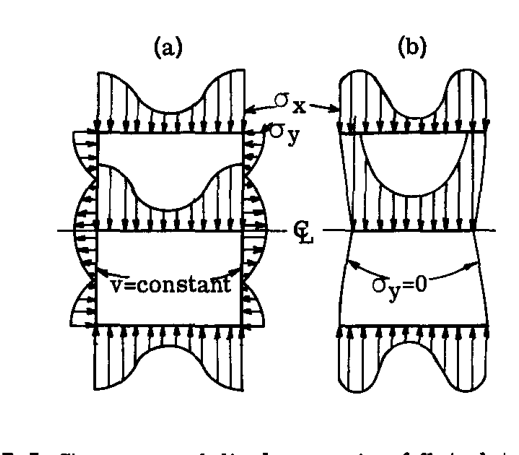

Fig. C7.5

**C7.6 圧潰応力に関するGerardの式**

以下の方程式は（文献3）から引用したものである。

アングル、管、V溝プレート、多重角部断面、および補強パネルのように、歪んだ非荷重端部を持つ断面の場合、次の圧潰応力方程式が $\pm 10$ %の制限範囲内で適用される。

$$\frac{F_{cs}}{F_{cy}} = 0.56 \left[ \left( \frac{g t^2}{A} \right)
\left( \frac{E}{F_{cy}} \right)^{1/2} \right]^{0.85}
\qquad ---\text{(C7.4)}$$

プレート、ティー、十字形、およびH断面のように、直線状の非荷重端部を持つ断面の場合、圧潰応力に関する次の方程式が $\pm 5$ %の制限範囲内で適用される。

$$\frac{F_{cs}}{F_{cy}} = 0.67 \left[ \left( \frac{g t^2}{A} \right)
\left( \frac{E}{F_{cy}} \right)^{1/2} \right]^{0.40}
\qquad ---\text{(C7.5)}$$

2つの角部を持つ断面、Z、J、およびチャンネル断面の場合、次の式が $\pm 10$ %の制限範囲内で適用される。

$$\frac{F_{cs}}{F_{cy}} = 3.2 \left[ \left( \frac{t^2}{A} \right) \left(
\frac{E}{F_{cy}} \right)^{1/3} \right]^{0.75}
\qquad ---\text{(C7.6)}$$

ここで、 * $F_{cs}$ = 断面の圧潰応力 (psi) * $F_{cy}$ = 圧縮降伏応力 (psi) * $t$ = 要素の板厚 (inches) * $A$ = 断面の面積 ( $\text{in.}^2$ ) * $E$ = 縦弾性係数 * $g$ = 複合断面を構成するフランジの数に、断面を一連のフランジに分割するために必要なカットの数を加えたもの。値を決定するための複合断面のカット方法については、図 C7.6を参照。

複合断面のカットオフまたは最大圧潰応力 $F_{cs}$ は、表 C7.1に示す値に制限されるべきであり、試験結果によってより高い値が実証される場合に限る。表 C7.1に示すカットオフ値は、間違いなく少し保守的である。式 (C7.4)、(C7.5)、および (C7.6) の設計曲線は、図 C7.7、C7.8、および C7.9に示されている。

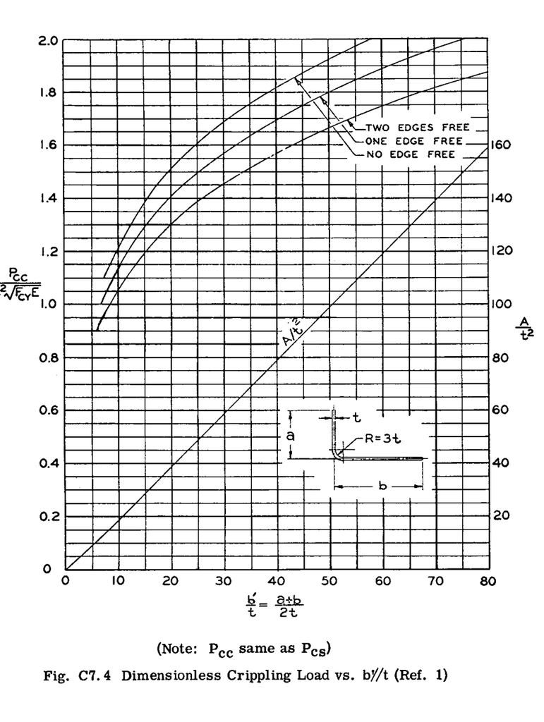

Fig. C7.4

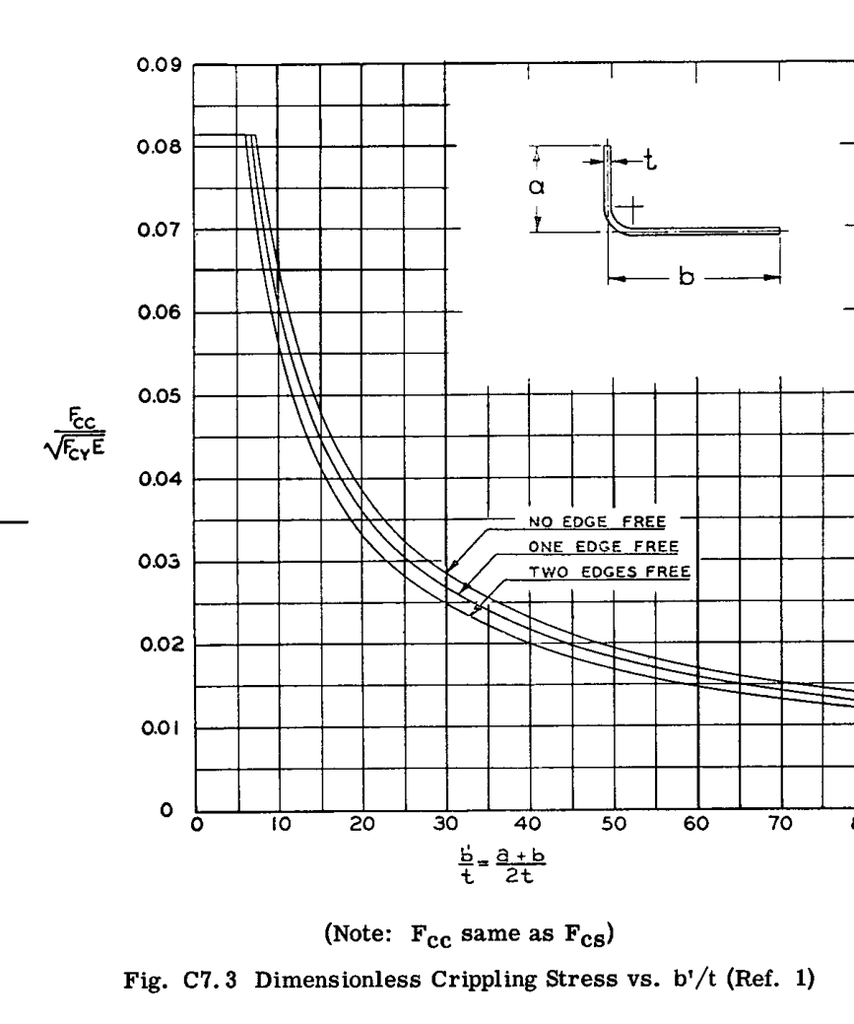

Fig. C7.3

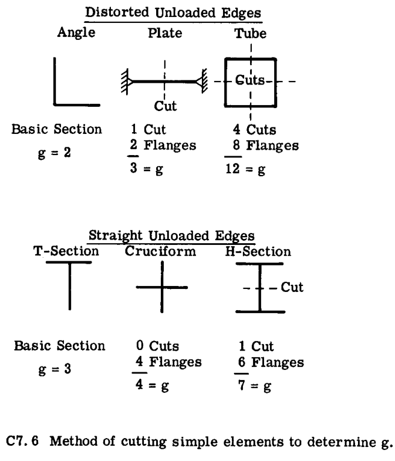

Fig. C7.6

**C7.7 被覆（クラッド）に対する補正**

多くの成形断面はアルクラッド（Alclad）シートから作られているため、クラッド被覆は座屈応力の値を低下させるように作用し、したがって、強度のこの低下を考慮するために補正係数 $\eta$ を使用しなければならない。（文献3）によるこの補正は、次の通りである。

$$\eta = \frac{[1 + 3(\sigma_{cl}/\sigma_{cr})f]}{1 + 3f}
\qquad ---\text{(C7.7)}$$

ここで、 * $\sigma_{cl}$ = クラッドの降伏応力 * $\sigma_{cr}$ = 座屈応力 * $f$ = 全厚さに対する全クラッド厚さの比。 $f = 0.10$ （Alclad 2024-T3の場合）および $0.08$ （Alclad 7075-T3の場合）。

**C7.8 圧潰応力の最大値**

複合断面のカットオフまたは最大圧潰応力は、より高い圧潰応力の使用を実証する試験結果が得られない限り、表 C7.1の値に制限されるべきである。

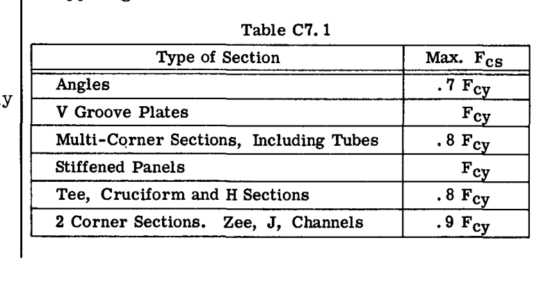

Table C7.1

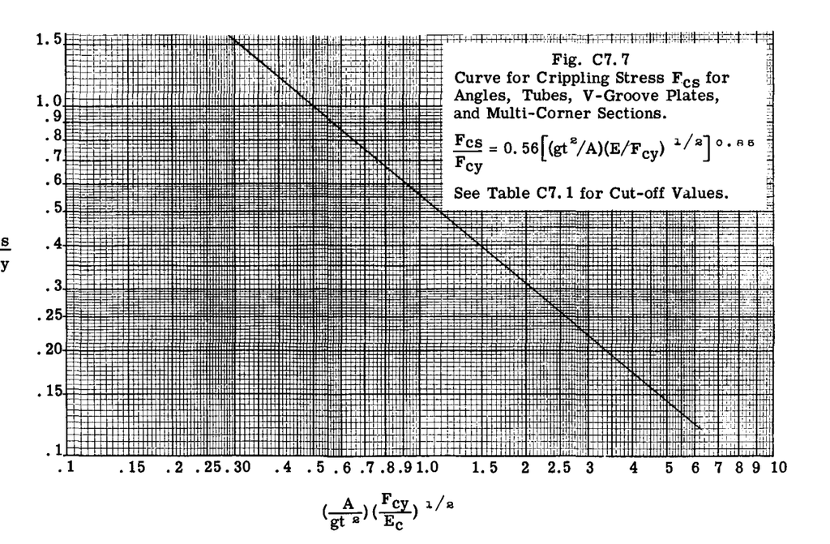

Fig. C7.7

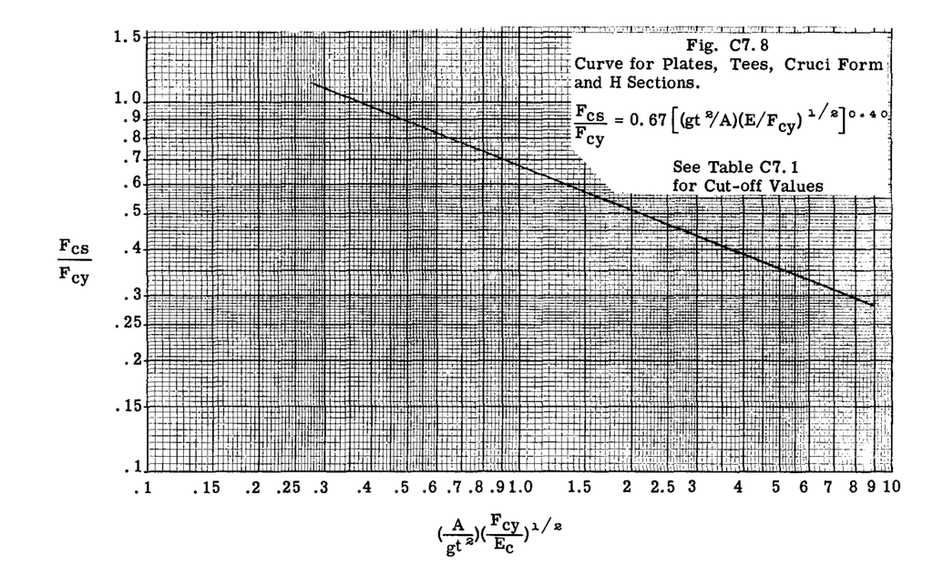

Fig. C7.8

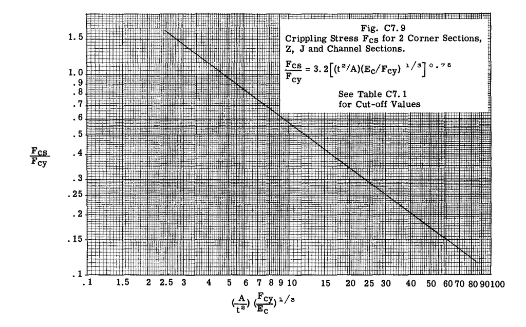

Fig. C7.9

**C7.9 リップおよびバルブによって生じる拘束**

成形断面において、自由縁を持つフランジ要素は、図aに示すように、幅がかなり狭いことがよくある。また、押出断面の場合、図bに示すようにバルブがよく使用される。その場合、リップまたはバルブが隣接する板要素に単純支持を提供するのに十分な大きさであるかという疑問が生じる。板要素の圧縮座屈係数は4.0であり、フランジ要素の圧縮座屈係数は0.43であるため、小さなリップまたはバルブを使用することで、係数の値を0.43よりかなり上に増加させることができ、したがって、より効率的な荷重支持要素を作り出すことができる。隣接する板要素に対して少なくとも単純支持端条件を与えるためのリップまたはバルブの寸法を決定する問題は、Windenburg（文献5）によって理論的に調査されている。彼の研究の結果は、次の設計基準を与えている。

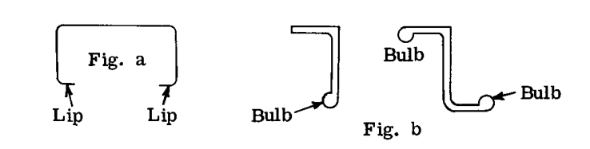

Fig. a, Fig. b

$$2.73 \frac{I_L}{b_f t^3} - \frac{A_L}{b_f t} \ge 5
\qquad ---\text{(C7.8)}$$

ここで、 $I_L$ と $A_L$ はそれぞれリップまたはバルブの断面二次モーメントと面積である（図 C7.10を参照）。

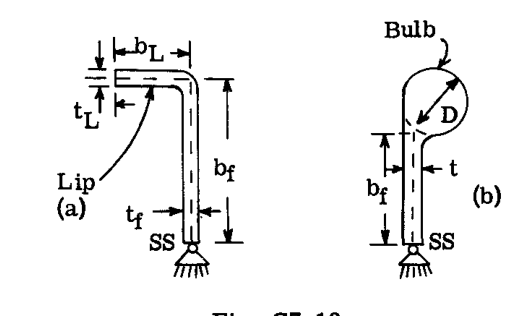

Fig. C7.10

図 C7.10aのリップについて、 $A_L = b_L t$ 、および $I_L = t b_L^3/3$ である。

これらの値を式 (C7.8) に代入すると、リップの寸法は次のように表される。

$$0.910 \left( \frac{b_L}{t} \right)^3 - \frac{b_L}{t} = 5 \frac{b_f}{t}
\qquad ---\text{(C7.9)}$$

$b_L$ と $t$ を決定するために、追加の要件が指定されている。すなわち、リップの座屈応力は、隣接する板要素の座屈応力以上でなければならない。

第C5章から、 $u_e = 0.3$ を使用した圧縮座屈係数は、フランジ要素に対しては0.388、板要素に対しては3.617である。したがって、

$$0.388 E \left( \frac{t_L}{b_L} \right)^2 \ge 3.617 E \left(
\frac{t_f}{b_f} \right)^2
\qquad ---\text{(C7.10)}$$

式 (C7.9) と (C7.10) から、次の関係が得られる。

$$\frac{b_L}{t_L} \le 0.328 \frac{b_f}{t_f}
\qquad ---\text{(C7.11)}$$

図 C7.11は、その結果を曲線として示している。

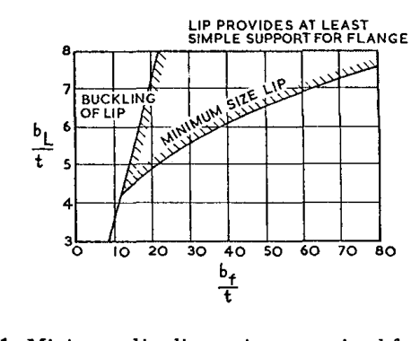

Fig. C7.11

押出断面では、図 C7.10bに示すように、自由縁を補強するために丸いバルブがよく使用される。板要素の中心線に関するバルブ面積の断面二次モーメントは、次の通りである。

$$I = \frac{\pi D^4}{64} + \frac{\pi D^2}{4} \left( \frac{D-t}{2}
\right)^2$$

リップの場合と同様に、バルブの座屈応力は、隣接する板要素の座屈応力以上でなければならず、これにより次の式が得られる。

$$\left( \frac{D}{t} \right)^4 - 1.6 \left( \frac{D}{t} \right)^3 - 0.374
\left( \frac{D}{t} \right)^2 = 7.44 \frac{b_f}{t}
\qquad ---\text{(C7.12)}$$

図 C7.12は、上記の方程式を表す設計曲線を示している。

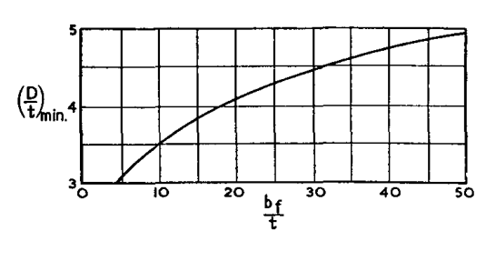

Fig. C7.12

**C7.10 圧潰応力の計算における例題**

**問題1.** 図aに示す等辺アングルの圧潰応力を求めよ。材料はアルミニウム合金 2024-T3である。

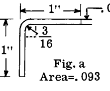

Fig. a

**方法1による解決**

材料特性は以下の通りである： * $F_{cy} = 40000$ 、 $E_c = 10,700,000$

この方法では、図 C7.3を使用する。図 C7.3の下部スケールのパラメータは $(a + b)/2t$ であり、ここで $(a)$ と $(b)$ はアングルの隣接する辺の中心線まで測定された辺の長さである。本例では、 $a = b = 1 - 0.025 = 0.975$ である。したがって、 $(a + b)/2t = 1.95/0.1 = 19.5$ となる。

図 C7.3より、下部スケールで19.5を使用し、2辺自由の曲線を用いると、左側のスケールから $\frac{F_{cc}}{\sqrt{F_{cy} E}} = 0.0330$ が読み取れる。アングルは1つだけなので、圧潰応力 $F_{cs} = F_{cc}$ は次のようになる。

$$0.0330 \times \sqrt{40,000 \times 10,700,000} = 21600 \text{ psi}$$

**方法2（Gerard法）による解決**

アングル断面に対しては、式 (C7.4) を使用する。この方程式のプロットは図 C7.7に示されている。下部スケールのパラメータは以下の通りである：

$$\left( \frac{A}{g t^2} \right) \left( \frac{F_{cy}}{E} \right)^{1/2}$$

ここで $A$ は断面面積であり、 $g$ はフランジの数にカット数を加えたものに等しく、アングル断面の場合は $g=2$ である。代入すると、

$$\left( \frac{0.093}{2 \times 0.05^2} \right) \left(
\frac{40,000}{10,700,000} \right)^{1/2} = 1.138$$

図 C7.7でこの値を使用すると、 $\frac{F_{cs}}{F_{cy}} = 0.50$ が読み取れる。したがって、

$$F_{cs} = 0.50 \times 40,000 = 20,000 \text{ psi}$$

**問題2.** 問題1と同じであるが、材料をアルミニウム合金 7075-T6に変更する。

- $F_{cy} = 67,000$ 、 $E_c = 10,500,000$

**方法1による解決**

$$F_{cs} = F_{cc} = 0.0330 \sqrt{67000 \times 10,500,000} = 28,000 \text{
psi}$$

**方法2による解決**

$$\left( \frac{0.093}{2 \times 0.05^2} \right) \left(
\frac{67,000}{10,500,000} \right)^{1/2} = 1.485$$

図 C7.7から、 $\frac{F_{cs}}{F_{cy}} = 0.40$ 、したがって、

$$F_{cs} = 0.40 \times 67,000 = 26800 \text{ psi}$$

**問題3.** 問題1と同じであるが、材料をチタン Ti-8Mn に変更する。 $F_{cy} = 110,000$ 、 $E_c = 15,500,000$

**方法1による解決**

$$F_{cs} = F_{cc} = 0.0330 \sqrt{110,000 \times 15,500,000} = 43000 \text{
psi}$$

**方法2による解決**

$$\left( \frac{0.093}{2 \times 0.05^2} \right) \left(
\frac{110,000}{15,500,000} \right)^{1/2} = 1.565$$

図 C7.7から、 $\frac{F_{cs}}{F_{cy}} = 0.38$ 、したがって、

$$F_{cs} = 0.38 \times 110,000 = 41,800 \text{ psi}$$

**問題4.** 図bに示すチャンネル断面の圧潰応力を求めよ。材料はアルミニウム合金 2024-T3である。 $F_{cy} = 40,000$ 、 $E_c = 10,700,000$ である。

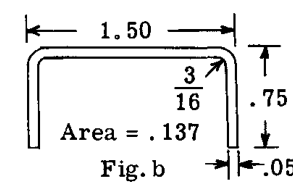

Fig. b

**方法1による解決**

図cに示すように、チャンネルは2つの等しいアングル要素 (1) と (2) から構成されている。これらは同じサイズであるため、1つのアングルの破壊応力を計算するだけでよい。

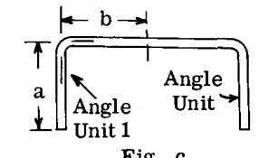

Fig. c

$$\frac{a+b}{2t} = \frac{0.725 + 0.725}{0.1} = 14.5$$

図 C7.3より、 $b'/t = 14.5$ に対して、 $\frac{F_{cc}}{\sqrt{F_{cy} E}} = 0.045$ （1辺自由の場合）が読み取れる。

したがって、

$$F_{cs} = F_{cc} = 0.045 \times \sqrt{40,000 \times 10,700,000} = 29400
\text{ psi}$$

**方法2による解決**

チャンネル断面に対しては、図 C7.9にプロットされている式 (C7.6) を使用する。図 C7.9の下部スケールのパラメータは、次の通りである。

$$\frac{A}{t^2} \left( \frac{F_{cy}}{E} \right)^{1/3} = \left(
\frac{0.137}{0.05^2} \right) \left( \frac{40,000}{10,700,000}
\right)^{1/3} = 8.50$$

図 C7.9から、 $\frac{F_{cs}}{F_{cy}} = 0.65$ 、したがって、

$$F_{cs} = 0.65 \times 40,000 = 26,000 \text{ psi}$$

**問題5.** 問題4と同じであるが、材料をアルミニウム合金 7075-T6に変更する。 $F_{cy} = 67,000$ 、 $E_c = 10,500,000$ である。

**方法1による解決**

$$\left( \frac{0.137}{0.05^2} \right) \left( \frac{67,000}{10,500,000}
\right)^{1/3} = 10.17$$

図 C7.9から、 $\frac{F_{cs}}{F_{cy}} = 0.57$ 、したがって、

$$F_{cs} = 0.57 \times 67,000 = 38,200 \text{ psi}$$

**問題6.** 図dに示す角形管の圧潰応力を求めよ。材料は 2024-T3 アルミニウム合金である。 $F_{cy} = 40,000$ 、 $E_c = 10,700,000$ である。

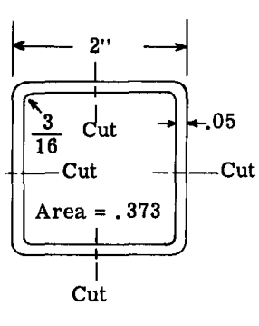

Fig. d

**方法1による解決**

角形管は、自由縁のない4つの等しいアングルから構成されているとみなされる。

$$_b'/t = (a + b)/2t = 1.95/0.1 = 19.5$$

図 C7.3から、上部の曲線（自由縁なし）を使用して、 $\frac{F_{cc}}{\sqrt{F_{cy} E}} = 0.0392$ を得る。したがって、

$$F_{cs} = F_{cc} = 0.0392 \times \sqrt{40,000 \times 10,700,000} = 25,600
\text{ psi}$$

**方法2による解決**

面積 $A = 0.373$ 。 $g = \text{カット数} + \text{フランジ数} = 4 + 8 = 12$ 。

長方形管の場合、式 (C7.4) または図 C7.7を使用する。

$$\frac{A}{g t^2} \left( \frac{F_{cy}}{E} \right)^{1/2} = \left(
\frac{0.373}{12 \times 0.05^2} \right) \left( \frac{40,000}{10,700,000}
\right)^{1/2} = 0.758$$

図 C7.7から、 $\frac{F_{cs}}{F_{cy}} = 0.70$ となる。

したがって、 $F_{cs} = 40,000 \times 0.70 = 28,000 \text{ psi}$

**問題7.** 問題6と同じであるが、材料を 300°Fの温度に1/2時間さらされたマグネシウム HK31A-O シートに変更する。

**方法1による解決**

第B1章の表B1.1から、 $F_{cy} = 11,100$ 、 $E_c = 6,160,000$ である。

$$F_{cs} = 0.0392 \sqrt{11,100 \times 6,160,000} = 10,250 \text{ psi}$$

**方法2による解決**

$$\frac{A}{g t^2} \left( \frac{F_{cy}}{E} \right)^{1/2} = \left(
\frac{0.373}{12 \times 0.05^2} \right) \left( \frac{11,100}{6,160,000}
\right)^{1/2} = 0.528$$

図 C7.7から、 $\frac{F_{cs}}{F_{cy}} = 0.96$

$$F_{cs} = 0.96 \times 11,100 = 10,600 \text{ psi}$$

表 C7.1から、長方形管のカットオフまたは最大圧潰応力は $0.8 F_{cy}$ 、すなわち $0.8 \times 11,100 = 8900 \text{ psi}$ である。したがって、試験によってより高い値が実証されない限り、圧潰応力は $8900 \text{ psi}$ とすべきである。

**問題8.** 問題6と同じであるが、材料をステンレス鋼 17-7PH (TH1050) に変更する。 $F_{cy} = 162,000$ 、 $E_c = 29,000,000$ である。

**方法1**

$$F_{cs} = 0.0392 \sqrt{162,000 \times 29,000,000} = 85,000 \text{ psi}$$

**方法2**

$$\left( \frac{0.373}{12 \times 0.05^2} \right) \left(
\frac{162,000}{29,000,000} \right)^{1/2} = 0.93$$

図 C7.7から、 $\frac{F_{cs}}{F_{cy}} = 0.595$ 。 $F_{cs} = 162,000 \times 0.595 = 96,200 \text{ psi}$ となる。

**問題9.**

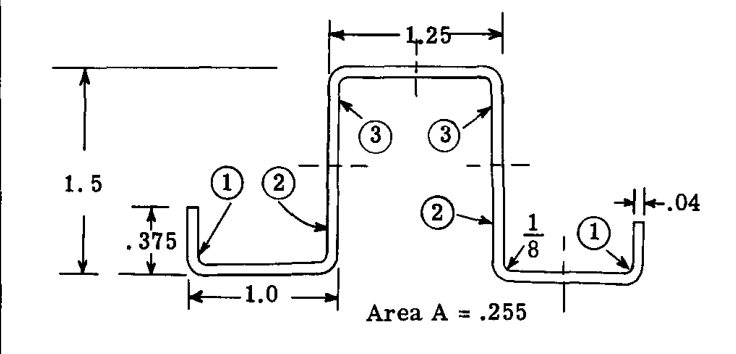

Fig. e

図eに示す成形断面の圧潰応力を、材料がアルミニウム合金 2024-T3である場合に求めよ。 $F_{cy} = 40,000$ 、 $E_c = 10,700,000$ である。

**方法1（Needham法）による解決**

断面は、図eの破線によって6つのアングル要素に分割される。対称性があるため、これらは (1) から (3) まで番号が振られている。

手順としては、各アングルの破壊荷重を求め、6つのアングル要素の合計を加算する。次に、圧潰応力はこの総荷重を断面面積で割ったものに等しくなる。

**アングル要素 (1)** （1辺自由）

$$b'/t = (a + b)/2t = [(0.375 - 0.02) + (0.5 - 0.02)] / 0.08 = 10.44$$

図 C7.3から、 $\frac{F_{cc}}{\sqrt{F_{cy} E}} = 0.06$

これより、 $F_{cc} = 0.06 \times \sqrt{40,000 \times 10,700,000} = 39,300 \text{ psi}$

アングルの面積 (1) = $0.0309 = A$

$$P_{cc} = 0.0309 \times 39,300 = 1215 \text{ lb.}$$

**アングル要素 (2)** 面積 = $0.0459$ （自由辺なし）

$$b'/t = (a+b)/2t = (0.48 + 0.73) / 0.08 = 15.1$$

図 C7.3から、 $\frac{F_{cc}}{\sqrt{F_{cy} E}} = 0.0475$

$$F_{cc} = \sqrt{40,000 \times 10,700,000} \times 0.0475 = 31,100 \text{
psi}$$

$$P_{cc} = 31,100 \times 0.0459 = 1428 \text{ lb.}$$

**アングル要素 (3)** 面積 = $0.0509$ （自由辺なし）

$$b'/t = (0.73 + 0.605) / 0.08 = 16.7$$

図 C7.3から、 $\frac{F_{cc}}{\sqrt{F_{cy} E}} = 0.046$

$$F_{cc} = 0.046 \times \sqrt{40,000 \times 10,700,000} = 30,200 \text{
psi}$$

$$P_{cc} = 0.0509 \times 30,200 = 1540 \text{ lb.}$$

$$F_{cs} = \frac{\sum P_{cc}}{\text{面積}} = \frac{2 \times 1215 + 2
\times 1428 + 2 \times 1540}{0.255} = 32,800 \text{ psi}$$

**方法2（Gerard法）による解決**

$$\frac{A}{g t^2} \left( \frac{F_{cy}}{E} \right)^{1/2}$$

$g = \text{フランジ数} + \text{カット数} = 12 + 5 = 17$ 。

上記の項に代入すると、

$$\left( \frac{0.255}{17 \times 0.04^2} \right) \left(
\frac{40,000}{10,700,000} \right)^{1/2} = 0.573$$

表 C7.1から、多重角部断面の場合、 $F_{cs}$ の最大値は、試験によってより高い値が実証されない限り、 $0.8 F_{cy}$ に制限されることが推奨されている。

$$F_{{cs}_{\text{max}}} = 0.8 \times 40,000 = 32,000 \text{ psi}$$

**問題10.** 図fに示す押出バルブアングルの材料が 2014-T6 押出アルミニウム合金である場合の圧潰応力を求めよ。

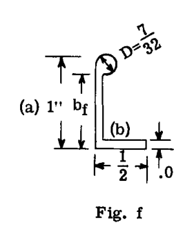

Fig. f

この特定のバルブ断面は、第A3章の表A3.16からセクションNo.2として採用されている。その表からの面積は $0.113 \text{ sq. in.}$ である。

**方法2（Gerard法）による解決**

この材料について、 $F_{cy} = 53,000$ 、 $E_c = 10,700,000$ である。

最初に生じる問題は、バルブが通常の角部と同等になるように、 $(a)$ 辺に端部剛性を与えるのに十分な大きさであるかということである。

図fにおいて、 $b_f = 0.78$ 、したがって $b_f/t = 15$ となる。

図 C7.12を参照すると、 $b_f/t$ の値が15の場合、少なくとも3.8の $D/t$ 比が必要であることがわかる。このバルブアングルの $D/t$ 値は $(7/32)/0.05 = 4.4$ であり、したがってバルブは角部を発達させるのに十分な剛性を持っている。次に生じる問題は、バルブアングルを依然として式 (C7.4) が適用されるアングル断面に分類すべきか、それともバルブがチャンネルの短い厚い辺として機能するチャンネルまたは2角部断面に分類すべきかということである。この場合、式 (C7.6) が適用される。

圧潰応力は、両方の方程式によって計算される。

式 (C7.4) または図 C7.7による場合：

バルブが完全な角部とみなされる場合、 $g = 4 \text{ フランジ} + 1 \text{ カット} = 5$ である。

$$\frac{A}{g t^2} \left( \frac{F_{cy}}{E_c} \right)^{1/2} = \left(
\frac{0.113}{5 \times 0.05^2} \right) \left( \frac{53,000}{10,700,000}
\right)^{1/2} = 0.636$$

図 C7.7から、

$F_{cs}/F_{cy} = 0.82$ 、したがって $F_{cs} = 0.82 \times 53000 = 43500 \text{ psi}$

式 (C7.6) または図 C7.9による場合：

$$\frac{A}{t^2} \left( \frac{F_{cy}}{E_c} \right)^{1/3} = \left(
\frac{0.113}{0.05^2} \right) \left( \frac{53,000}{10,700,000}
\right)^{1/3} = 7.70$$

図 C7.9から、 $F_{cs}/F_{cy} = 0.7$ 、したがって $F_{cs} = 0.7 \times 53,000 = 37,100 \text{ psi}$ となる。

おそらく、圧潰応力の最良の推定値は、上記の2つの結果の平均、すなわち $40,300 \text{ psi}$ であろう。

表 C7.1において、アングルのいわゆるカットオフ応力は $0.7 F_{cy}$ であり、チャンネルは $0.9 F_{cy}$ である。平均値または $0.8 F_{cy}$ を使用すると、バルブアングルに関する限られた試験結果のため、最大許容値として $F_{cs} = 0.8 \times 53,000 = 42,400 \text{ psi}$ が得られる。

バルブまたはリップが完全な角部を想定するのに必要な剛性を発達させない場合、バルブは追加のフランジとしてのみみなされ、 $g$ カウントは5の代わりに4になり、したがって圧潰応力が低下する。

## 有効板幅

**C7.11 イントロダクション**

本章におけるこれまでの議論は、成形または押出断面が単独で機能する場合、すなわちその長さに沿って他の構造物に固定されていない場合の圧潰応力を扱ってきた。しかし、翼や胴体などの航空宇宙用車両の主要構造は、アングル、ゼット、ティーなどの取り付けられた、または一体的に製作された補強材によって強化された外板被覆を伴う。外板と補強材は一緒に変形しなければならないため、外板は圧縮荷重を支持することになり、重量削減が非常に重要である航空宇宙構造設計において、外板のこの荷重支持能力を無視することは保守的すぎる。

外板の有効幅の質問は、多くの個人によって検討されてきた。Von Karman、Sechler、Timoshenko、Newell、Frankland、Marguerre、Fischel、Gerardなどの名前は、有効板幅に関する現在の知識と密接に関連している。

座屈後のこの応力分布を決定するために、様々な理論的研究（文献6）が行われてきた。一般に、それらは長くて複雑な方程式を導く。設計目的のための単純な基礎を提供するために、図dの均一な応力を受けるとみなされる外板の有効幅 $w$ を見つける試みがなされており、これは図cの真の不均一な応力分布下の外板と同じ総外板強度を与える。

**C7.12 外板有効幅**

図 C7.13aは、補強材に固定された連続した平坦な薄い板を示しており、ユニット全体が一様な圧縮荷重を受けている。外板の座屈強度までは、外板と補強材に同じ材料を仮定すると、（図b）のように、圧縮応力分布は補強材と外板の両方にわたって一様である。荷重が増加すると、外板は補強材間で座屈し、座屈応力より大きな応力を支持しなくなる。しかし、補強材に近づくにつれて、固定されている補強材によって安定化されている外皮は、より高い応力を受けることができ、補強材の直上では、外板が補強材に連続的に接続されていると仮定すると、外板は補強材の極限強度と同じ応力を受けることができる。図cは、外板が座屈した後の一般的な応力分布を示している。この分布は、補強材によって提供される拘束の程度とパネルの寸法に依存する。

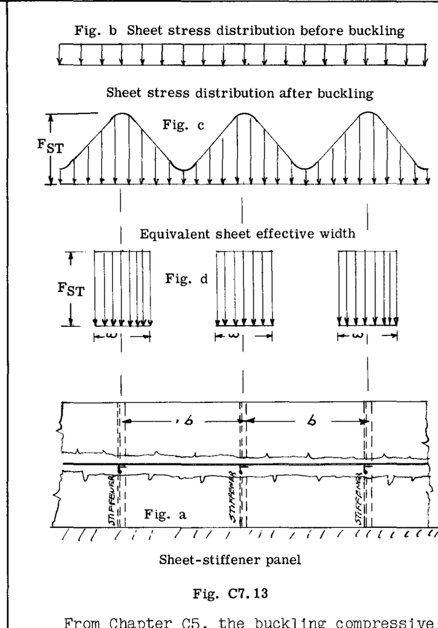

Fig. C7.13

第C5章から、板パネルの座屈圧縮応力は次の通りである。

$$F_{cr} = \frac{k_c \pi^2 E}{12(1 -
u_e^2)} \left( \frac{t}{b} \right)^2
\qquad ---\text{(C7.13)}$$

外板が取り付けられている補強材が単純支持に等しい境界拘束を提供すると仮定し、 $k_c = 4.0$ 、ポアソン比 $u_e$ が0.3とされる場合、式 (C7.13) は次のように簡略化される。

$$F_{cr} = 3.60 E (t/b)^2
\qquad ---\text{(C7.14)}$$

最初に提案されたVon-Karman-Sechler法は、端部が単純支持された板の極限強度は板の幅に依存しないことが実験によって示されていたため、 $F_{cr}$ が材料の降伏応力に等しい場合に、(b) の代わりに幅 $(w)$ について式 (C7.14) を解くことから構成されていた。したがって、式 (C7.14) は次のように変更される。

$$F_{cy} = 3.60 E (t/w)^2$$

これより、

$$w = 1.90 t \sqrt{E/F_{cy}}
\qquad ---\text{(C7.15)}$$

補強材の圧潰または局所破壊応力は材料の降伏強度を超える可能性があるため、式 (C7.15) は後に $F_{cy}$ をストリンガー（縦通材）内の応力 $F_{ST}$ に置き換えることによって変更され、これにより次式が与えられた。